# Week 5: Intro to Bayesian Inference

PS 818 - Statistical Models

Anton Strezhnev

strezhnev@wisc.edu

University of Wisconsin-Madison

September 29, 2025

$$\require{cancel}
\DeclareMathOperator*{\argmin}{arg\,min}$$

$$\DeclareMathOperator*{\argmax}{arg\,max}$$

# Previously

- **Generalized Linear Models**
  - Extending our **linear predictor** $X_i^{\prime}\beta$ to non-linear transformations of the CEF
  - **Three** elements: A distribution for $Y_i$, a linear predictor, and a link function $g()$: $g(E[Y_i | X_i]) = X_i^{\prime}\beta$
  - Estimation via Maximum Likelihood - nicely-behaved likelihoods when $Y_i$ is in the exponential family.

# This week

- **Bayesian inference**
  - What happens when we define a distribution for our “beliefs” about $\theta$
  - How do we obtain the **posterior** distribution $\theta | \mathbf{Y}$?
- **Defining a Bayesian Model**
  - Writing down the data-generating process
  - “Plate notation” for concise model summaries
- **Estimation** via computation
  - Most posterior distributions can’t be expressed in closed form
  - But we can construct an algorithm to **sample** from that distribution
  - Metropolis-Hastings algorithm - “Gibbs sampling” as a special case

# Intro to Bayesian Inference

# Bayesian inference

- In the **frequentist** paradigm, we took a particular approach to thinking about *randomness* when trying to learn about an unknown parameter $\theta$ using observed data $\mathbf{Y}$
  - $\theta$ is an unknown **constant**
  - $\mathbf{Y}$ are random variables
  - $\hat{\theta}$ is our estimator of $\theta$ - it’s a function of random random variables
  - Probabilities reflect behavior in *repeated samples*
- **Bayesian** inference takes a different approach to the problem. Rather than treating $\theta$ as a constant, we consider it to be **random** as well!
  - Probabilities reflect **beliefs** about a particular quantity
  - $f(\theta)$ denotes our *prior* beliefs about the value of $\theta$
  - $f(\theta | \mathbf{Y})$ is the *posterior* distribution given the observed data. This is our target of inference
  - $\mathbf{Y}$ are still random variables…but the posterior distribution *conditions* on them
- We derive the posterior using **Bayes rule**

  $$f(\theta | \mathbf{Y}) = \frac{f(\mathbf{Y} | \theta)}{f(\mathbf{Y})} f(\theta)$$

# Bayesian inference

- The denominator can be written as an integral over all of the possible values of $\theta$ (marginalizing over $\theta$)

  $$f(\mathbf{Y}) = \int f(\mathbf{Y},\theta)d\theta = \int f(\mathbf{Y}|\theta)f(\theta)d\theta$$
- So often we’ll write the posterior distribution *up to a proportionality constant* as

  $$\underbrace{f(\theta | \mathbf{Y})}_{\text{posterior}} \propto \underbrace{f(\mathbf{Y} | \theta)}_{\text{likelihood}} \times \underbrace{f(\theta)}_{\text{prior}}$$

# Bayesian inference

- In addition to the posterior distribution of the parameters $\theta$, we’ll often want to generate “forecasts” of an out-of-sample $\tilde{Y}$ conditional on what we have observed
  - This involves integrating over the posterior values of the parameter $\theta$

  $$\begin{align*}f(\tilde{Y}|\mathbf{Y}) &= \int f(\tilde{Y}, \theta | \mathbf{Y}) d\theta\\
  &= \int f(\tilde{Y}| \theta, \mathbf{Y}) f(\theta | \mathbf{Y}) d\theta\\
  &= \int f(\tilde{Y}| \theta) f(\theta | \mathbf{Y}) d\theta\end{align*}$$

# Bayesian inference

- We also might reason about two different values of $\theta$: $\{\theta_1, \theta_2\}$ and their relative odds. This has a nice expression in terms of the *prior* times a *likelihood ratio*

  $$\frac{f(\theta_1|\mathbf{Y})}{f(\theta_2|\mathbf{Y})} = \frac{f(\theta_1)}{f(\theta_2)} \times \frac{f(\mathbf{Y}|\theta_1)}{f(\mathbf{Y}|\theta_2)}$$
- Inference on the posterior is often referred to as **updating** the prior and often can be conceptualized in terms of *sequential* changes to our beliefs about the parameter.
- Suppose we have two samples $\mathbf{Y}_1$ and $\mathbf{Y}_2$. Our posterior can be written as:

  $$\begin{align*}f(\theta | \mathbf{Y}_1, \mathbf{Y}_2) &\propto f(\mathbf{Y}_2, \mathbf{Y}_1 | \theta) \times f(\theta) \\ &\propto f(\mathbf{Y}_2 | \mathbf{Y}_1, \theta) \times f(\mathbf{Y}_1 | \theta) \times f(\theta) \\ &\propto f(\mathbf{Y}_2 | \mathbf{Y}_1, \theta) \times f(\theta | \mathbf{Y}_1) \end{align*}$$
- The posterior becomes the new “prior”!

# Application: Predicting Elections

- We’d like to predict U.S. House of Representatives elections using data from the prior Presidential election at the county level
  - *Pettigrew (2018)* assembled the 2018 US House returns at the county level
  - Available as `us-house-wide.csv` on the Course Github
- For each county $i$, $i \in \{1, 2, \dotsc, N\}$, we observe:
  - $Y_i$: The number of votes for the Democratic candidate county
  - $n_i$: The number of votes cast in total in that county
- Let’s start by building a simple model and going from there.
  - Assume $Y_i$ is a draw from a binomial distribution with a total number of of trials $K_i$ and “success” probability $\pi$.
  - $\pi_i$ comes from a **Beta** distribution with *hyperparameters* $\alpha_0$ and $\beta_0$

  $$Y_i \sim \text{Binomial}(n_i, \pi_i)$$
  $$\pi_i \sim \text{Beta}(\alpha_0, \beta_0)$$

# Plate notation

- A common method of writing statistical models is via **plate notation**
  - These concisely encode independence and dependence assumptions across parameters and data.

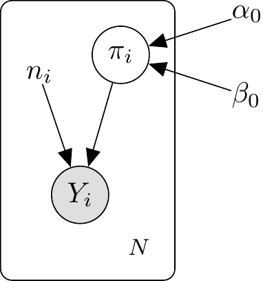

# Features of a Bayesian model

- There are four types of variables in a Bayesian model
  - **Observed Data**: Variables that have a probability distribution but on whose observed values we condition - $Y_i$
  - **Known Constants**: Fixed quantities that do not have probability distributions (e.g. regressors or other features of the nodes) - $n_i$, $N$, $\alpha_0$, $\beta_0$
  - **Deterministic quantities**: Transformations of other variables
  - **Latent parameters**: Variables that have a probability distribution that we do not observe - $\pi_i$

# Features of a Bayesian model

- Sometimes the known constants are *actually* known by us (e.g. $N$ or $n_i$) and in other cases they are *assumed to be known*
  - These are typically parameters of the prior distribution which are called **hyperparameters** (here: $\alpha_0$ and $\beta_0$)
  - The hyperparameters govern the distribution of the prior crucially, its mean and variance.
- In Bayesian inference, we are interested in obtaining either the posterior of the latent parameters *or* integrating them out (in the latter case, they are sometimes referred to as “nuisance” parameters)
  - Here, we want to obtain $f(\pi_i | \mathbf{Y})$
  - When writing the posterior, we’ll often omit the implicit conditioning on the observed constants.

# The Likelihood

- Remember the posterior distribution is proportional to the **likelihood** times the **prior**

  $$\underbrace{f(\pi_i | \mathbf{Y})}_{\text{posterior}} \propto \underbrace{f(\mathbf{Y} | \pi_i)}_{\text{likelihood}} \times \underbrace{f(\pi_i)}_{\text{prior}}$$
- First, let’s derive the **likelihood** $f(\mathbf{Y} | \pi_i)$
  - Since the $Y_i$ are independent conditional on $\pi_i$, we can write:

  $$f(\mathbf{Y} | \pi_i) = \prod_{j=1}^N f(Y_j | \pi_i)$$
- Next, for $j \neq i$, we have $f(Y_j | \pi_i) = f(Y_j)$ since $Y_j$ only depends on $\pi_j$. That’s just a constant term and drops out of the posterior distribution, leaving

  $$f(\pi_i | \mathbf{Y}) = f(\pi_i | Y_i) \propto f(Y_i | \pi_i) f(\pi_i)$$

# The Likelihood and Prior

- What’s $f(Y_i | \pi_i)$? We’ve defined it as the binomial PMF

  $$f(Y_i | \pi_i) = {n_i \choose Y_i} \pi_i^{Y_i}(1- \pi_i)^{n_i - Y_i}$$
- What about the prior? $f(\pi_i)$? We’ve chosen the **beta** distribution

  $$f(\pi_i) = \frac{\Gamma(\alpha_0)\Gamma(\beta_0)}{\Gamma(\alpha_{0} + \beta_{0})} \pi_i^{\alpha_0 - 1}(1- \pi_i)^{\beta_0 - 1}$$
- The Beta distribution has some notable features.
  - It’s mean: $E[\pi_i] = \frac{\alpha_0}{\alpha_0 + \beta_0}$
  - It’s variance $Var(\pi_i) = \frac{\alpha_0\beta_0}{(\alpha_0 + \beta_0)^2(\alpha + \beta + 1)}$

# The Beta Distribution

- Let’s see how the parameters influence the shape of the beta. $\text{Beta}(2,2)$:

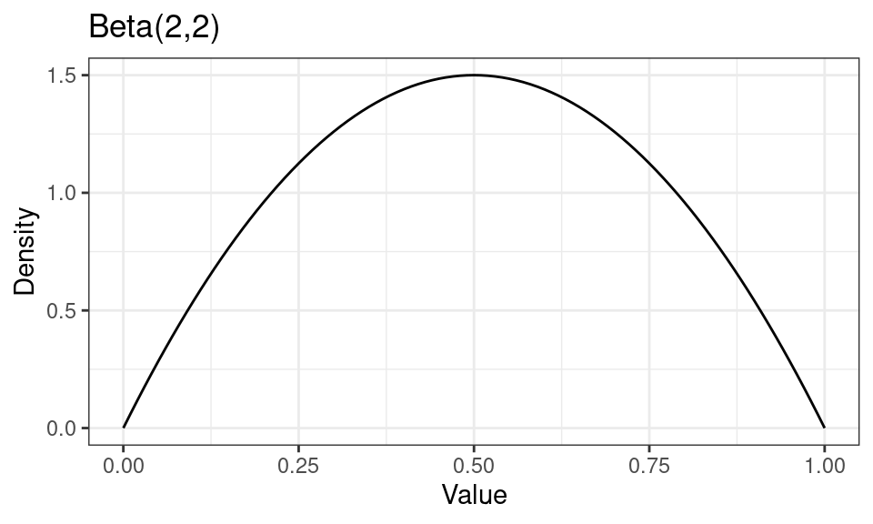

# The Beta Distribution

- $\text{Beta}(100,200)$:

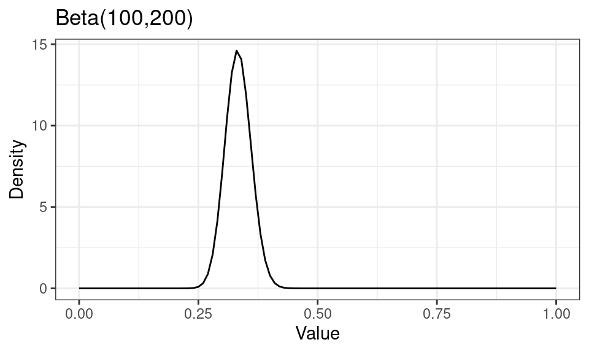

# Choosing a prior

- There are two ways to think about choosing a prior distribution
  - **Informative** prior - Use the prior to encode our existing beliefs about the parameter
  - **Uninformative/Diffuse** prior - Pick a prior that will have the least impact on the posterior distribution
- We also need to consider the *shape* of the prior distribution $f(\pi_i)$
  - Why did we pick the Beta distribution?
  - Because it has a special property when combined with a binomial likelihood. It is a **conjugate** prior to the binomial likelihood.
- **Conjugate prior**: A prior distribution is *conjugate* to a particular likelihood if the posterior distribution is of the same form as the prior
  - $f(\theta)$ is beta; $f(\mathbf{Y} | \theta)$ is binomial; $f(\theta | \mathbf{Y})$ is beta

# Choosing a prior

- In this case, $\pi_i$ must be between $0$ and $1$, so we already have some information.
- One possible choice for an *uninformative* prior is the uniform distribution - each parameter value is equally likely:
  $$f(\pi_i) \propto 1$$
  - In settings where the parameter takes on values $(-\infty, \infty)$, we could still consider a “uniform” prior but it will be **improper** as it’s not a density that integrates to $1$
- For $\pi_i \in (0, 1)$, the uniform prior corresponds to the $\text{Beta}(1,1)$ distribution
  - Originally proposed by Bayes.

# Choosing a prior

- Haldane proposed instead $Beta(0,0)$ - notably this is *improper*

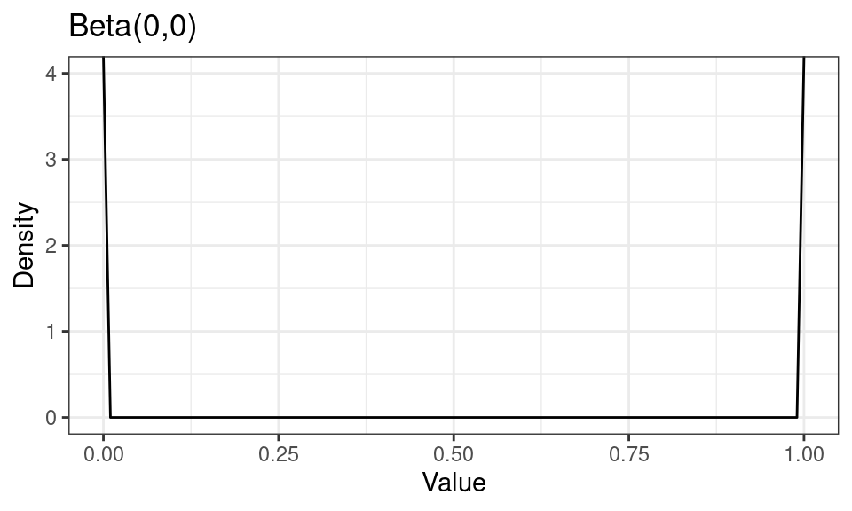

# Choosing a prior

- And Jeffreys proposed $\text{Beta}(.5, .5)$

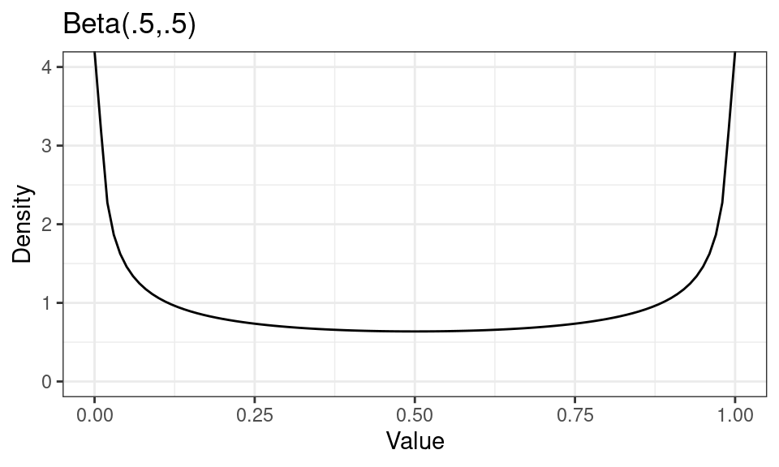

# The posterior density

- We’ve mentioned that $f(\pi_i | Y_i)$ is a beta distribution let’s show that!

  $$f(\pi_i | \mathbf{Y}) \propto f(Y_i | \pi_i) f(\pi_i)$$
- Plug in the densities (we’ll drop any multiplicative constants that don’t depend on $\pi_i$)

  $$f(\pi_i | \mathbf{Y}) \propto \left[\pi_i^{Y_i}(1- \pi_i)^{n_i - Y_i}\right]\times\left[\pi_i^{\alpha_0 - 1}(1- \pi_i)^{\beta_0 - 1}\right]$$
- Adding the exponents

  $$f(\pi_i | \mathbf{Y}) \propto \pi_i^{Y_i + \alpha_0 - 1}(1- \pi_i)^{n_i - Y_i + \beta_0 - 1}$$
- And we can recognize this as the **kernel** of the beta distribution with parameters $\alpha = Y_i + \alpha_0$ and $\beta = n_i - Y_i + \beta_0$

# Quantities of interest

- Once we have a posterior distribution, we typically will report **summaries** in the style of our typical frequentist point and interval estimates.
  - Note, however, that these have a different interpretation in the Bayesian framework.
- **Point** summaries
  - *Posterior Mean*: $\hat{\theta} = E[\theta | \mathbf{Y}]$
  - *Posterior Mode*: $\hat{\theta} = \argmax_{\theta} p(\theta | \mathbf{Y})$
- **Credible interval**: A $95\%$ credible interval $(l_{95}, h_{95})$ is a range of values that contains $95\%$ of the posterior density

  $$\int_{l_{95}}^{h_{95}} f(\theta | \mathbf{Y})d\theta = .95$$
- There is no one unique credible interval! As a result, there are a few common choices for how to construct a credible interval
  - **Highest Density** interval (HDI) - no values outside of the interval have higher density than values *inside* the interval
  - **Equal-tailed** interval (ETI) - the probability of being below the lower limit is equal to the probability above the upper limit

# Application

- Let’s take a look at the elections data. Start by loading it in

```r
elections <- read_csv("data/us-house-wide.csv")
```

- One feature of this county-level House data is that because House districts don’t perfectly overlap counties, we have some county-district combinations with very few voters!
  - Consider my home county: **Hennepin County, MN**

```
# A tibble: 3 × 10
  state county   fipscode fipscode2  office   district total.votes    dem    rep
  <chr> <chr>    <chr>    <chr>      <chr>    <chr>          <dbl>  <dbl>  <dbl>
1 MN    Hennepin 27053    2705300000 US House 3             304621 172435 131604
2 MN    Hennepin 27053    2705300000 US House 5             318328 251739  65471
3 MN    Hennepin 27053    2705300000 US House 6                475    170    305
# ℹ 1 more variable: other <dbl>
```

- MN-6 only has 475 votes from Hennepin County.

# Application

- Let’s get the posterior distribution for $\pi_i$ for MN-6 in Hennepin County under an uninformative uniform prior

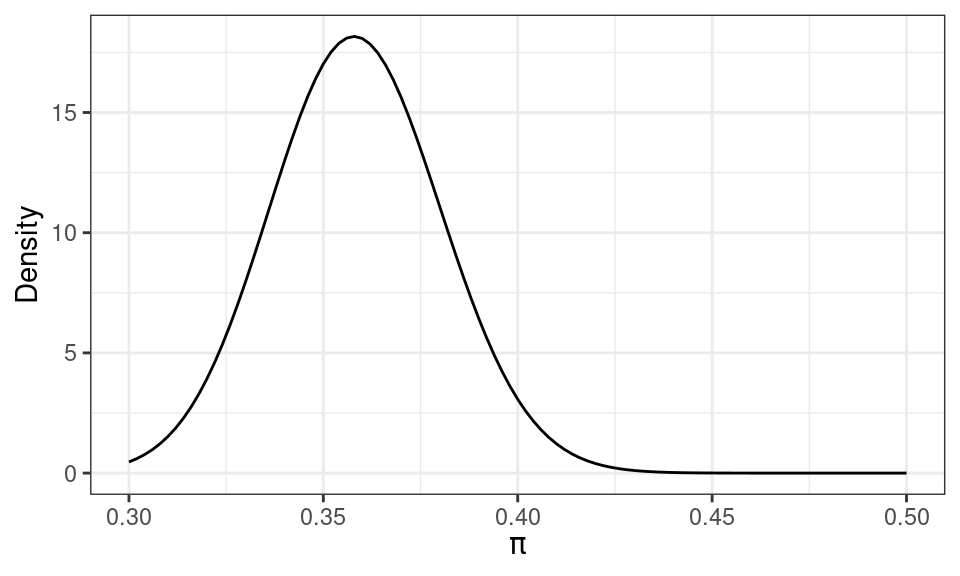

# Application

- We know the form of the beta mean, so our posterior mean estimate is

```r
posterior_mean <- posterior_alpha/(posterior_alpha + posterior_beta)
posterior_mean
```

```
[1] 0.358
```

- And we can obtain an equal-tailed 95% credible interval simply via the quantile function

```r
posterior_ci <- c(qbeta(.025, shape1=posterior_alpha, shape2=posterior_beta), qbeta(.975, shape1=posterior_alpha, shape2=posterior_beta))
posterior_ci
```

```
[1] 0.316 0.402
```

# Application

- But we have some more information from the other counties in the district

```r
mn6 <- elections %>% filter(state=="MN"&district == 6)
mn6
```

```
# A tibble: 8 × 10
  state county  fipscode fipscode2 office district total.votes   dem   rep other
  <chr> <chr>   <chr>    <chr>     <chr>  <chr>          <dbl> <dbl> <dbl> <dbl>
1 MN    Anoka   27003    27003000… US Ho… 6             107459 45178 62062   219
2 MN    Benton  27009    27009000… US Ho… 6              15922  5800 10081    41
3 MN    Carver  27019    27019000… US Ho… 6              18457  6511 11938     8
4 MN    Hennep… 27053    27053000… US Ho… 6                475   170   305     0
5 MN    Sherbu… 27141    27141000… US Ho… 6              38996 13271 25665    60
6 MN    Stearns 27145    27145000… US Ho… 6              53937 22204 31666    67
7 MN    Washin… 27163    27163000… US Ho… 6              21545  9085 12445    15
8 MN    Wright  27171    27171000… US Ho… 6              58935 20113 38769    53
```

- What if we instead constructed our prior such that its mean was centered on the average of all the other counties?
  - We can control the strength of the prior via the prior variance

# Application

```r
prior_mean <- sum(mn6 %>% filter(county != "Hennepin") %>% pull(dem))/sum(mn6 %>% filter(county != "Hennepin") %>% pull(total.votes))
prior_variance <- (prior_mean*(1-prior_mean))/1000
# Convert these to alpha/beta
prior_alpha <- (((1 - prior_mean)/prior_variance) - (1/prior_mean))*prior_mean^2
prior_beta <- prior_alpha*(1/prior_mean - 1)
```

# Application

- Let’s plug-in the new prior parameters

```r
posterior2_alpha <- mn6_hennepin$dem + prior_alpha
posterior2_beta <- mn6_hennepin$total.votes - mn6_hennepin$dem + prior_beta
# Plot the posterior
mn6_posterior2 <- ggplot() + xlim(.3, .5)  +  geom_function(fun=dbeta, args=list(shape1=posterior_alpha, shape2=posterior_beta), lty=2, lwd=1.5, col="dodgerblue") +
  theme_bw() + xlab(expression(pi)) +
  ylab("Density") + geom_vline(xintercept=prior_mean, lty=2, lwd=1.5, col="indianred") +
  geom_function(fun=dbeta, args=list(shape1=posterior2_alpha, shape2=posterior2_beta),lwd=1.5)
```

# Application

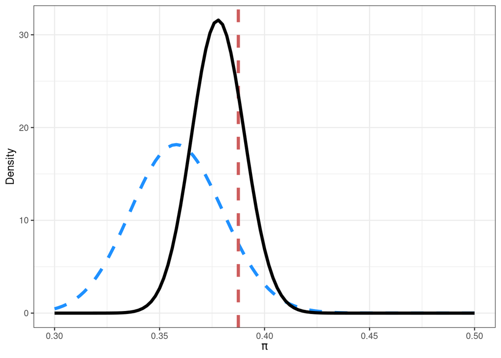

# Application

- Our new posterior mean

```r
posterior2_mean <- posterior2_alpha/(posterior2_alpha + posterior2_beta)
posterior2_mean
```

```
[1] 0.378
```

- And 95% credible interval

```r
posterior2_ci <- c(qbeta(.025, shape1=posterior2_alpha, shape2=posterior2_beta), qbeta(.975, shape1=posterior2_alpha, shape2=posterior2_beta))
posterior2_ci
```

```
[1] 0.353 0.403
```

# Application

- The posterior mean can be thought of as a “weighted average” of the prior mean and the MLE
  - The weights are controlled by the variance of the prior.
  - Can interpret the hyper-parameters for this case - $\alpha_0$ and $\beta_0$ - as the number of “previously observed” counts.
- Stronger priors $\leadsto$ narrower credible intervals
  - But it takes a *lot* more data to move the posterior distribution from the prior.
- Often the prior serves to **regularize** our estimates
  - We want our estimates to be “pulled” towards a particular value if there’s very little data.
  - A common type of “regularizing” prior is designed to attenuate our estimates to $0$ - we’ll talk about this in a later week!

# Connections with Frequentism

- You’ll notice that for the uninformative uniform prior, our posterior mode is equivalent to the MLE
  - If $f(\theta) \propto 1$, $f(\theta|\mathbf{Y}) = f(\mathbf{Y}|\theta)$
- More generally, for most well-behaved priors and likelihoods, the **Bernstein-von Mises** theorem states that as $n \to \infty$…
  - …the posterior distribution $f(\theta | \mathbf{Y})$ will converge to a **normal** distribution
  - …centered at the true parameter $\theta_0$
  - …with variance-covariance matrix equal to the inverse Fisher information
- Essentially: In large samples, posterior distributions converge to the sampling distribution of the MLEs

# Markov-Chain Monte Carlo

# Markov-Chain Monte Carlo

- In many settings, we have this problem in computing the posterior

  $$f(\theta | \mathbf{Y}) = \frac{\overbrace{f(\mathbf{Y}|\theta)}^{\text{Easy!}} \times \overbrace{f(\theta)}^{\text{Easy!}}}{\underbrace{f(\mathbf{Y})}_{\textbf{HARD!}}}$$
- The **prior** $f(\theta)$ has a known distribution (sometimes up to a proportionality constant)
- The **likelihood** $f(\mathbf{Y} \ \theta)$ has a known distribution specified by our data-generating process
- In general, we write our model so that the joint density of the data and the parameters $f(\mathbf{Y}, \theta) = f(\mathbf{Y} | \theta) f(\theta)$ factors very neatly
- But $f(\mathbf{Y})$ is a tough to evaluate integral!

  $$f(\mathbf{Y}) = \int f(\mathbf{Y},\theta)d\theta$$
- We’ve used the trick of having a **conjugate prior** which lets us know the distribution of the posterior

# Markov-Chain Monte Carlo

- Markov-Chain Monte Carlo methods allow us to generate a sample of observations from the target posterior **even when we don’t know it** as long as we can evaluate a function that is **proportional** to the posterior
  - **Monte Carlo**: Use repeated samples to obtain numeric approximations of key quantities
  - **Markov-Chain**: The samples from the posterior are constructed via a “chain” that has the Markov property
- **Our Goal**: Generate a monte carlo sample $\{\theta^{(1)}, \theta^{(2)}, \theta^{(3)}, \dotsc \}$ of arbitrary length such that the sequence of draws **converges** to a **stationary distribution** that is the target posterior
- This sample is a **markov chain** in that the distribution of the $(i+1)$th draw depends on the value of the $i$th, but only on that past value

  $$f(\theta^{(i+1)} | \mathbf{Y}, \theta^{(i)}, \theta^{(i-1)}, \dotsc, \theta^{(1)}) = f(\theta^{(i+1)} | \mathbf{Y}, \theta^{(i)})$$
- Important note: our samples from the target posterior will be **dependent**

# Metropolis-Hastings Algorithm

- The foundational algorithm for generating MCMC samples is the **Metropolis-Hastings** algorithm.
  - **Crucially**: We can sample from almost *any* distribution (though some distributions are better than others)
- The algorithm relies on two key concepts to generate another sample $\theta^{(i+1)}$ given the past sample value $\theta^{(i)}$:
  - The **proposal distribution** - A probability distribution $f(\theta^{(i+1)} | \theta^{(i)})$ that generates our “proposal” value
  - The **acceptance probability** - A calculation for the probability of “accepting” the proposed value or rejecting it

# Metropolis-Hastings Algorithm

- To generate the markov chain of $M$ samples from the target posterior distribution $\{\theta^{(1)}, \theta^{(2)}, \theta^{(3)}, \dotsc, \theta^{(M)}\}$, the **Metropolis-Hastings** algorithm iterates between two steps:
1. **Proposal**: Conditional on the current value $\theta$, generate a draw $\theta^*$ from $Q(\theta^* | \theta)$ where $Q$ is the proposal distribution.
2. **Accept/Reject**: With probability $\alpha$, “accept” the proposal and set $\theta^{(i+1)} = \theta^*$ - otherwise “reject” and set $\theta^{(i+1)} = \theta$

$$\alpha = \min\bigg\{1, \frac{f(\mathbf{Y}|\theta^*)f(\theta^*)}{f(\mathbf{Y}|\theta)f(\theta)} \times \frac{Q(\theta | \theta^*)}{Q(\theta^* | \theta)} \bigg\}$$

- **Intuitively** - If the proposal distribution is symmetric…
  - …if the unnormalized posterior density is higher at the proposed rather than the current location, **always accept**
  - …if the unnormalized posterior density is lower at the proposed rather than current location, **maybe accept**

# Proposal Distribution

- Our choice of $Q$ governs how quickly the Markov Chain will “converge” to the true posterior
  - We want to choose a proposal distribution that could “eventually” propose each value in the domain of $\theta$
  - We also want a proposal distribution that generates a high acceptance probability $\alpha$
- It is common to choose a proposal distribution that is **symmetric** such that
  $$\frac{Q(\theta | \theta^*)}{Q(\theta^* | \theta)} = 1$$
- For $\theta \in (-\infty, \infty)$, common to propose $\theta^*$ from a $\text{Normal}(\theta, \Omega)$
  - That is, from a normal distribution centered on the “current” parameter with an arbitrarily chosen variance $\Omega$
  - This is **symmetric** since the chances of proposing $\theta^*$ from $\theta$ are the same as the chances of proposing $\theta$ from $\theta^*$

# Proposal Distribution

- Another alternative would be a $\text{Uniform}(\theta - \Delta, \theta + \Delta)$
  - Uniform distribution centered at $\theta$ where every value in the interval has density $\frac{1}{2\Delta}$
- For parameters that are constrained to $(0, 1)$, a simple choice would be to sample from the
  $$\text{Uniform}(0,1)$$
  - Trivially symmetric since the density is a constant.
  - But likely to generate bad proposals!
- We’re usually better off transforming our parameter to an unconstrained value and sampling there

# Proposal Distribution

- To get some intuition, it’s worth considering the case where somehow we could generate independent samples from the true posterior and

$$Q(\theta^*|\theta) = f(\theta^* | \mathbf{Y})$$

- What is our acceptance probability in this scenario?

$$\frac{f(\mathbf{Y}|\theta^*)f(\theta^*)}{f(\mathbf{Y}|\theta)f(\theta)} \times \frac{f(\theta|\mathbf{Y})}{f(\theta^*|\mathbf{Y})} = \frac{f(\theta^*|\mathbf{Y})f(\mathbf{Y})}{f(\theta|\mathbf{Y})f(\mathbf{Y})} \times \frac{f(\theta|\mathbf{Y})}{f(\theta^*|\mathbf{Y})} = 1$$

- If we were somehow proposing from the true posterior distribution, Metropolis-Hastings would **always accept** each proposal!

# Illustration

- Let’s go back to our posterior distribution for the Democratic vote share in the part of MN-6 that is in Hennepin County

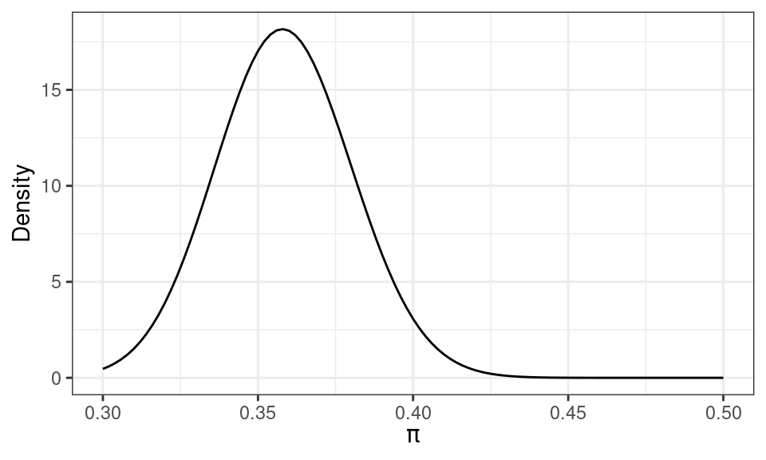

- In this case, we calculated the posterior directly since it was beta, but suppose we couldn’t?

# Illustration

- Let’s construct our MCMC sampler. First, let’s choose a proposal distribution
  - For $\pi_i \in (0, 1)$, we could use a Beta, but the Beta isn’t symmetric
  - $\text{Uniform}(0, 1)$ would generate a lot of bad proposals
- Instead, let’s transform $\pi_i$ to be unbounded. Define $\theta_i = \log\bigg(\frac{\pi_i}{1-\pi_i}\bigg)$
  - We’ll sample $\theta$s and convert them back to $\pi$ when we evaluate the likelihood and prior
  - An intuitive distribution $Q(\theta^* | \theta)$ would be the standard logistic distribution centered on $\theta$. It’s **symmetric**!

# Illustration

```r
set.seed(60637)
logistic <- function(x) 1/(1 + exp(-x)) # Helper Function
logit <- function(x) log(x/(1-x))
M <- 100000  # Number of MCMC samples
pi_mcmc <- rep(NA, M) # Vector to store our samples
pi_mcmc[1] <- .5 # Pick a starting value
```

# Illustration

```r
for (i in 1:(M-1)){ # For i in 1:(M-1)
  ## Step 1 - Proposal
  theta_i <- logit(pi_mcmc[i])
  theta_star <- rlogis(1, location = theta_i)
  ## Step 2 - Accept/Reject
  lik_star <- dbinom(mn6_hennepin$dem, mn6_hennepin$total.votes, prob = logistic(theta_star))
  prior_star <- dbeta(logistic(theta_star), shape1 = 1, shape2=1)
  lik_current <-  dbinom(mn6_hennepin$dem, mn6_hennepin$total.votes, prob = logistic(theta_i))
  prior_current <- dbeta(logistic(theta_i), shape1 = 1, shape2=1)
  Q_star_current <- dlogis(theta_star, location=theta_i) # This is all optional b/c of symmetry
  Q_current_star <- dlogis(theta_i, location=theta_star)
  #Assemble the acceptance ratio
  ar <- ((lik_star*prior_star)/(lik_current*prior_current))*(Q_current_star/Q_star_current)
  # Choose to accept or reject
  accept <- rbinom(1,1,min(1,ar))
  # Store the next value
  pi_mcmc[i+1] <- logistic(theta_star)*accept + logistic(theta_i)*(1-accept)
}
```

# Illustration

- Let’s first see how the chain progresses by generating the **trace plot**

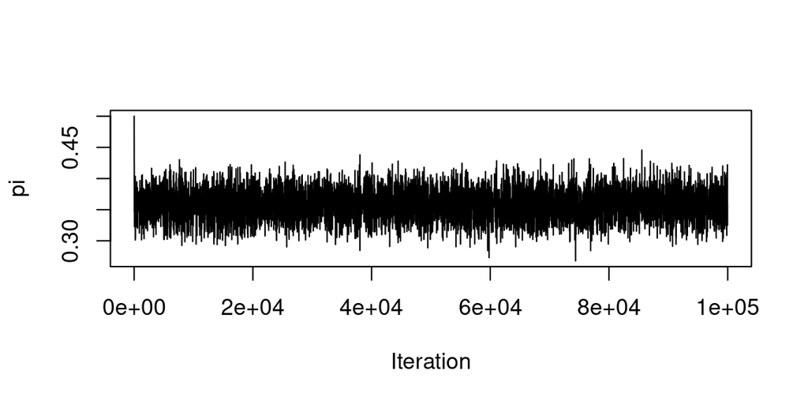

- You’ll see that it takes a bit for the chain to reach the area of the posterior with the most mass
  - If we started closer to the “mass” of the distribution, we would have converged faster
- In practice, we will throw away some number of our initial samples as a **burn-in** period, since we know that the chain needs some time to reach the stationary distribution.
  - Here we’ll drop the first $5000$ samples and keep the rest

# Illustration

- Our ideal trace plots have no clear trends - in such a case, we consider the chain to have reached its stationary distribution

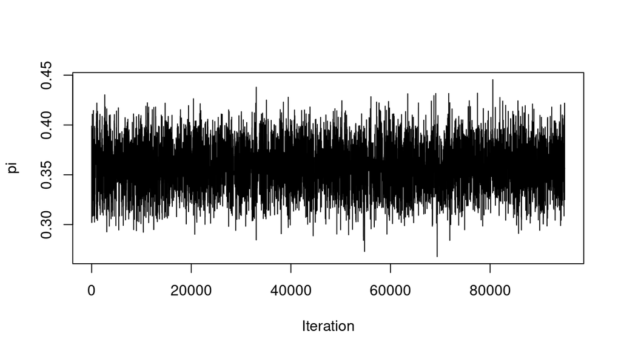

- Note that trace plots are **diagnostics** they don’t prove that the chain has “mixed,” but a lot of jumps or stagnant periods would suggest that our chain needs to run longer (or we need to choose a better proposal distribution!)

# Illustration

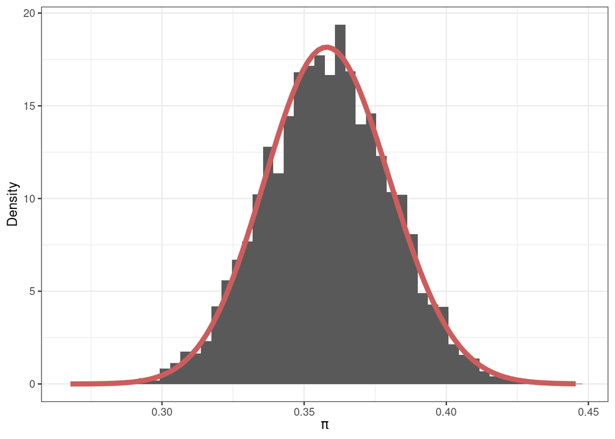

# Illustration

- We can compute summaries like the posterior mean or a 95% credible interval by taking summaries of the MCMC sample

```r
posterior_mcmc_mean <- mean(pi_mcmc_use)
posterior_mcmc_mean
```

```
[1] 0.358
```

```r
posterior_mean
```

```
[1] 0.358
```

# Illustration

- We get very close to the true posterior (and can get closer with more iterations)

```r
posterior_mcmc_ci <- quantile(pi_mcmc_use, c(.025, .975))
posterior_mcmc_ci
```

```
 2.5% 97.5%
0.315 0.401
```

```r
posterior_ci
```

```
[1] 0.316 0.402
```

# Multiple parameters

- In this example, we’ve focused on estimating a single parameter. Suppose instead we have $K$ parameters: $\theta = \{\theta_1, \theta_2, \theta_3, \dotsc, \theta_K\}$
- With multiple parameters, we’d need a multivariate proposal distribution (like a multivariate normal)
  - But this can be hard and mixing is often very slow with multivariate proposals.
- Instead, we can use **Gibbs sampling** generating each update $\theta^{(i+1)}_k$ conditional on the other current values of the other parameters $\theta^{(i)}_{-k}$
  - Importantly, if we **can** sample from the conditional distribution $\theta_k | \theta_{k-1}, \mathbf{Y}$ we can get proposals with acceptance probability 1
  - Even if we can’t, we can use a M-H step for that parameter

# Gibbs Sampling

- The **Gibbs sampling** algorithm generates updates $\theta^{(i+1)} = \{\theta^{(i+1)}_1, \theta^{(i+1)}_2, \theta^{(i+1)}_3, \dotsc, \theta^{(i+1)}_K\}$ by sampling in sequence:

$$\begin{align*}\theta_1^{(i+1)} &:= \theta^*_1 \sim f(\theta_1 | \mathbf{Y}, \theta_2^{(i)}, \theta_3^{(i)}, \dotsc \theta_K^{(i)})\\
\theta_2^{(i+1)} &:= \theta^*_2 \sim f(\theta_2 | \mathbf{Y}, \theta_1^{(i+1)}, \theta_3^{(i)}, \dotsc \theta_K^{(i)})\\
&\vdots\\
\theta_k^{(i+1)} &:= \theta^*_k \sim f(\theta_k | \mathbf{Y}, \theta_1^{(i+1)}, \theta_2^{(i+1)}, \dotsc \theta_{k-1}^{(i+1)},\theta_{k+1}^{(i)} \dotsc, \theta_K^{(i)})\\
&\vdots\\
\theta_K^{(i+1)} &:= \theta^*_K \sim f(\theta_K | \mathbf{Y}, \theta_1^{(i+1)}, \theta_2^{(i+1)}, \dotsc \theta_{K-1}^{(i+1)})\end{align*}$$

- **Important**: Sampling from the conditionals $f(\theta_k | \theta_{-k}, \mathbf{Y})$ is often easier to do than sampling from the marginal distribution $f(\theta_k | \mathbf{Y})$.
  - In fact, we’ll often introduce latent variables to make a Gibbs sampling algorithm work where it otherwise wouldn’t. This is called **data augmentation**

# Gibbs Sampling

- To see why sampling from the conditionals works, consider the implied MH acceptance probability when we treat the conditional distribution $f(\theta_{k} | \theta_{-k}^{(i)} , \mathbf{Y})$ as the proposal distribution $Q$

$$\alpha = \frac{f(\mathbf{Y}|\theta^*_k, \theta^{(i)}_{-k})f(\theta^*_k, \theta_{-k}^{(i)})}{f(\mathbf{Y}|\theta^{(i)}_k, \theta^{(i)}_{-k})f(\theta^{(i)}_k, \theta_{-k}^{(i)})} \times \frac{f(\theta^{(i)}_k|\mathbf{Y}, \theta_{-k}^{(i)})}{f(\theta^{*}_k|\mathbf{Y}, \theta_{-k}^{(i)})}$$

- Rewrite the numerator/denominator in terms of the posterior and the data (and recall that $f(\mathbf{Y})$ cancels)

$$\alpha = \frac{f(\theta^*_k, \theta^{(i)}_{-k}|\mathbf{Y})}{f(\theta^{(i)}_k, \theta^{(i)}_{-k}|\mathbf{Y})} \times \frac{f(\theta^{(i)}_k|\mathbf{Y}, \theta_{-k}^{(i)})}{f(\theta^{*}_k|\mathbf{Y}, \theta_{-k}^{(i)})}$$

# Gibbs Sampling

- Factor the posteriors

$$\alpha = \frac{f(\theta^*_k| \theta^{(i)}_{-k},\mathbf{Y}) \times f(\theta^{(i)}_{-k}|\mathbf{Y})}{f(\theta^{(i)}_k | \theta^{(i)}_{-k}, \mathbf{Y}) \times f(\theta^{(i)}_{-k}|\mathbf{Y})} \times \frac{f(\theta^{(i)}_k|\mathbf{Y}, \theta_{-k}^{(i)})}{f(\theta^{*}_k|\mathbf{Y}, \theta_{-k}^{(i)})}$$

- Everything cancels so that $\alpha = 1$
  - So Gibbs sampling is a special case of Metropolis-Hastings where the proposal distribution choice **guarantees** acceptance.

# Bayesian Regression

# Application: Predicting Elections

- Now suppose that instead of observing counts, we look at the democratic party vote share in county $i$ in the 2018 House elections (imagine we summed over all of the votes in all of the districts in that county).
  - Let $Y_i$ denote the share of votes going to the democratic party candidate in 2018 in county $i$.
- We want to generate a predictive model based on $X_i$, (here, we’ll just be using the democratic presidential vote share in 2016, but we’ll be adding more as we go).

# Bayesian Normal Model

- The conventional “normal” Bayesian regression model assumes

$$Y_i | X_i, \beta, \sigma^2 \sim \text{Normal}(X_i^{\prime}\beta, \sigma^2)$$
$$\beta | \sigma^2 \sim \text{Normal}(\beta_0, \sigma^2B^{-1}_0)$$
$$\sigma^2 \sim \text{Inverse-Gamma}(\frac{c_0}{2}, \frac{d_0}{2})$$

- In this case, $\beta_0$, $B_0$, $c_0$ and $d_0$ are all hyper-parameters
- This is referred to as the “Normal-Inverse-Gamma” model as the joint prior distribution on $\beta, \sigma^2$ is Normal-Inverse Gamma and it happens to also be the **conjugate prior** for the case with unknown $\beta$ and $\sigma^2$
  - So the posterior is known in closed form to be **Normal-Inverse-Gamma**
  - And conditional on $\sigma^2$, $\beta | \mathbf{X}, \mathbf{Y}, \sigma^2$ is also normally distributed!
- A common simplification is to make $\beta$ and $\sigma^2$ marginally independent

$$\beta \sim \text{Normal}(\beta_0, B_0^{-1})$$

# Plate notation

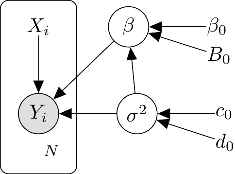

# Application: Predicting Elections

```r
# Aggregate the house data to counties
elections_county <- elections %>% group_by(fipscode) %>% summarize(state=state[1], county=county[1],
                                                                   total.votes = sum(total.votes),
                                                                   dem = sum(dem))

# Merge in 2015 Presidential
pres_2016 <- read_csv("data/clinton_2016_vote.csv")
elections_county <- elections_county %>% left_join(pres_2016 %>% dplyr::select(county_fips, candidatevotes, totalvotes),
                                                   by=c(fipscode="county_fips"))

# Generate vote shares
elections_county$dem2018 <- elections_county$dem/elections_county$total.votes
elections_county$dem2016 <- elections_county$candidatevotes/elections_county$totalvotes

# Drop missing
elections_county <- elections_county %>% filter(!is.na(dem2018)&!is.na(dem2016))
```

# Metropolis-Hastings

- Set up the regression

```r
X_mat <- model.matrix(dem2018 ~ dem2016, data=elections_county)
Y <- elections_county$dem2018
K <- ncol(X_mat) # Number of beta parameters
```

- Set up a diffuse prior

```r
beta_0 <- rep(0, K)
B_inv_0 <- solve(diag(rep(1/9, K)))
c_0 = 0.001
d_0 = 0.001
```

- Set up the MCMC

```r
M <- 40000  # Number of MCMC samples
burnin <- 5000
beta_mcmc <- matrix(nrow = M, ncol=K) # Vector to store our samples
beta_mcmc[1,] <- c(0,1) # Pick a starting value
sigma_mcmc <- rep(NA, M)
sigma_mcmc[1] <- 1
```

# Metropolis-Hastings

- Write some functions to evaluate the likelihood and priors

```r
log_lik_norm <- function(b, sigma, Y, X){
  linpred <- X%*%b
  sum(dnorm(Y, mean=linpred, sd=sigma, log=T))
}
```

# Metropolis-Hastings

```r
set.seed(60637)
for (i in 1:(M-1)){ # For i in 1:(M-1)
  ## Beta
    ## Step 1 - Proposal
    beta_star <- as.vector(mvtnorm::rmvnorm(1, mean  = beta_mcmc[i,], sigma=.00001*diag(K)))
    ## Step 2 - Accept/Reject
    lik_star_beta <- log_lik_norm(beta_star, sigma_mcmc[i], Y, X_mat)
    lik_current_beta <- log_lik_norm(beta_mcmc[i,], sigma_mcmc[i], Y, X_mat)

    prior_star_beta <- mvtnorm::dmvnorm(beta_star, mean = beta_0, sigma = B_inv_0, log=T)
    prior_current_beta <- mvtnorm::dmvnorm(beta_mcmc[i,], mean = beta_0, sigma = B_inv_0, log=T)

    ## Accept/reject
    ar_beta <- exp( lik_star_beta + prior_star_beta - lik_current_beta - prior_current_beta)
    accept_beta <- rbinom(1,1,min(1,ar_beta))
    beta_mcmc[i+1,] <- beta_star*accept_beta + beta_mcmc[i,]*(1-accept_beta)

  ## Sigma
    ## Step 1 - Proposal
    sigma_log <- rnorm(1, mean = log(sigma_mcmc[i]), sd=.01)
    sigma_star <- exp(sigma_log)

    ## Step 2 - Accept/Reject
    lik_star_sigma <- log_lik_norm(beta_mcmc[i+1,], sigma_star, Y, X_mat)
    lik_current_sigma <- log_lik_norm(beta_mcmc[i+1,], sigma_mcmc[i], Y, X_mat)
    # The trick here is independence - otherwise if \sigma^2 appeared in the prior for \beta, we'd need another term
    prior_star_sigma <- log(MCMCpack::dinvgamma(sigma_star^2, shape = c_0/2, scale = d_0/2))
    prior_current_sigma  <-  log(MCMCpack::dinvgamma(sigma_mcmc[i]^2, shape = c_0/2, scale = d_0/2))

    ## Accept/reject
    ar_sigma <- exp(lik_star_sigma + prior_star_sigma - lik_current_sigma - prior_current_sigma)
    accept_sigma <- rbinom(1,1,min(1,ar_sigma))
    sigma_mcmc[i+1] <- sigma_star*accept_sigma + sigma_mcmc[i]*(1-accept_sigma)

}
```

# Convergence

- $\beta_0$

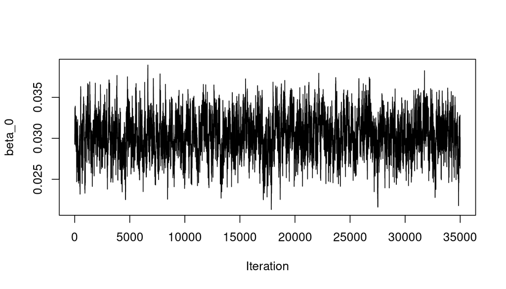

# Convergence

- $\beta_1$

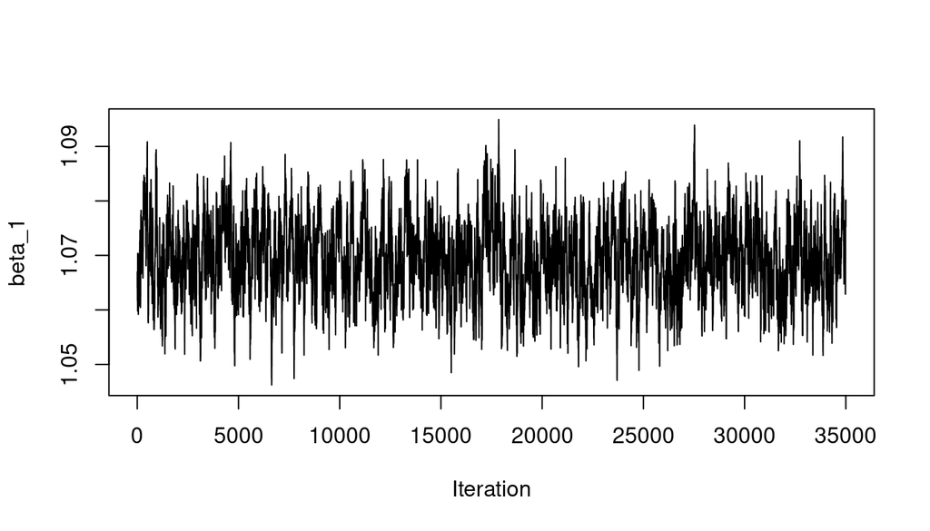

# Convergence

- $\sigma$

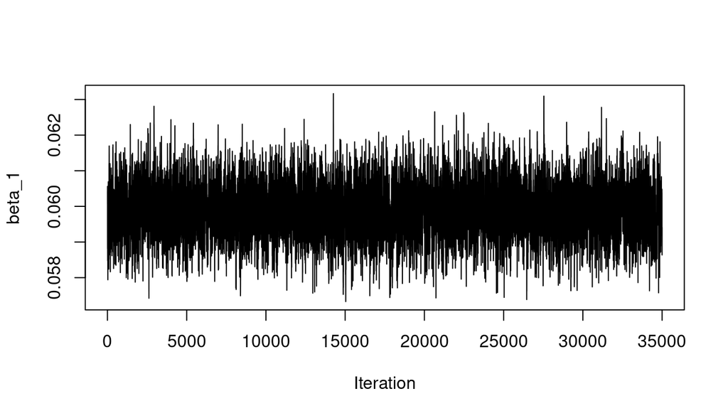

# Summaries

$\beta_0$

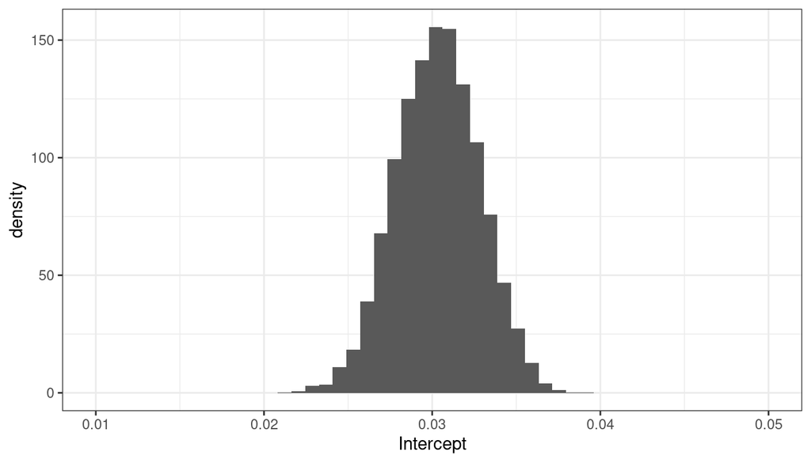

# Summaries

$\beta_1$

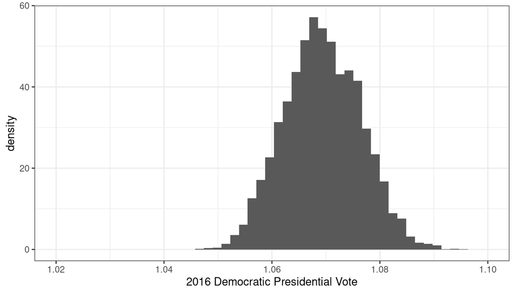

# Summaries

- Overlay the data and regression

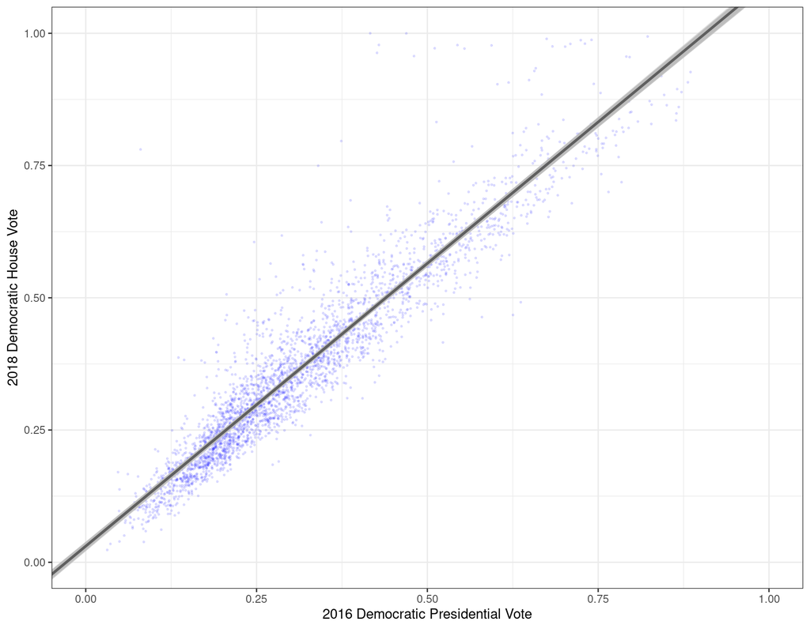

# Summaries

- Posterior means and 95% credible intervals

```r
summary_results <- data.frame(variable = c("Intercept", "dem2016"), pm = colMeans(beta_mcmc_out),
                              ci95_lower = apply(beta_mcmc_out, 2, function(x) quantile(x, .025)),
                              ci95_upper = apply(beta_mcmc_out, 2, function(x) quantile(x, .975)))

summary_results
```

```
           variable     pm ci95_lower ci95_upper
Intercept Intercept 0.0303     0.0255     0.0351
dem2016     dem2016 1.0694     1.0561     1.0832
```

# Gibbs sampler

- Let’s check against an existing Gibbs sampling implementation from `MCMCpack`

```r
set.seed(60637)
library(MCMCpack)
gibbs_results <- MCMCpack::MCMCregress(dem2018 ~ dem2016, burnin=burnin, mcmc=M-burnin,
                                       beta.start = c(0, 1), b0=beta_0, B_0 = diag(rep(1/9, K)),
                                       c0 = c_0, d0=d_0, data=elections_county)
```

# Gibbs sampler

```r
summary(gibbs_results)
```

```
Iterations = 5001:40000
Thinning interval = 1
Number of chains = 1
Sample size per chain = 35000

1. Empirical mean and standard deviation for each variable,
   plus standard error of the mean:

               Mean       SD Naive SE Time-series SE
(Intercept) 0.03051 2.49e-03 1.33e-05       1.34e-05
dem2016     1.06864 7.13e-03 3.81e-05       3.86e-05
sigma2      0.00359 9.23e-05 4.94e-07       4.94e-07

2. Quantiles for each variable:

               2.5%     25%     50%     75%   97.5%
(Intercept) 0.02568 0.02882 0.03051 0.03217 0.03544
dem2016     1.05464 1.06385 1.06863 1.07342 1.08252
sigma2      0.00341 0.00352 0.00359 0.00365 0.00377
```

# Diagnostics

- The trace plots for the beta coefficients using Gibbs sampling have a lot less visible dependence!

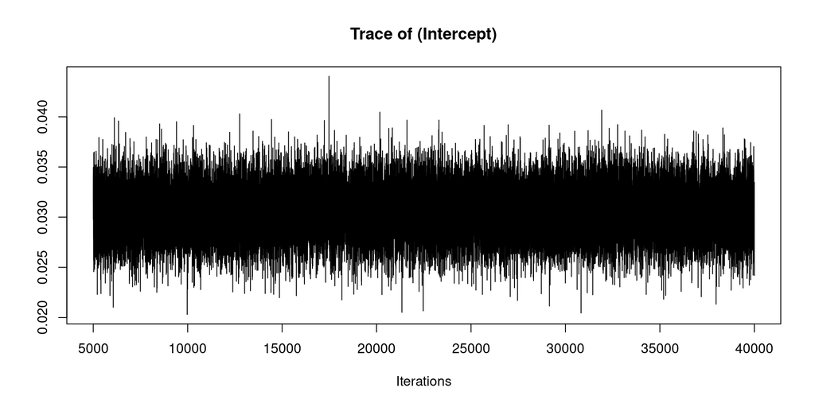

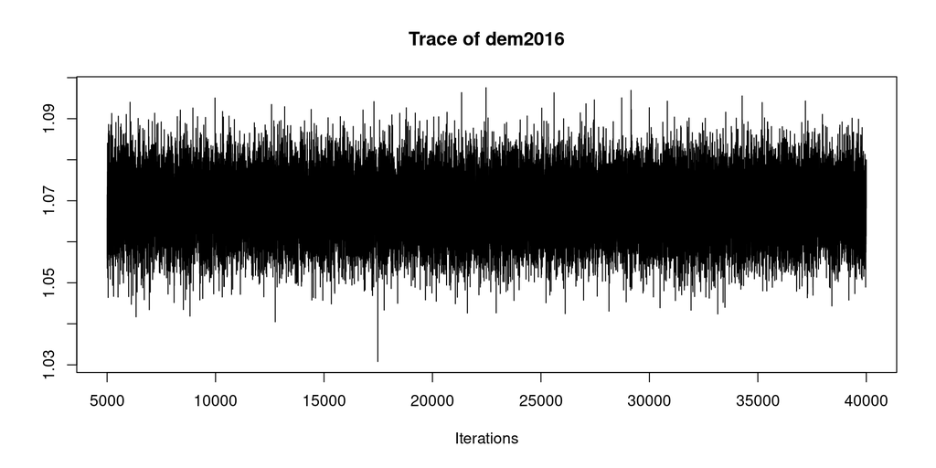

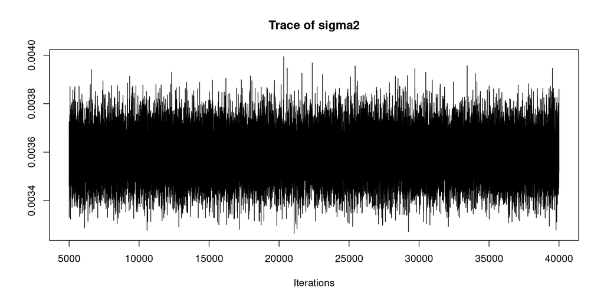